title: “Homework 2” author: “Alp Çıtıroğlu” date: “10/05/2021” output: html_document —

1)Introduction

Clothing CPI shows the purchasing power of people and also an indicator that shows the economies performance. And this CPI value is express montly so we should analye this value monthly. Our aim is to forecast the future CPI values about clothing and footwear in April 2021.

2. Data Manipulation

The monthly data of CPI index of clothing and footwear is imported from EVDS.Also I import some regressors which are related to CPI Index. These regressors are Dolar exchange rate, Inflation rate, Interest rate and a survey data which is the probability of saving over next 12 months.

I delete the first column which is date and add it to end. And I add names to other columns like Clothes_CPI, Dolar, Survey, Faiz and Inflation

```
##    Clothes_CPI    Dolar   Survey    Faiz Inflation       date
## 1:      266.87 7.873881 30.64730 19.5020     11.89 2020-10-01
## 2:      270.77 8.003324 27.84356 21.0825     14.03 2020-11-01
## 3:      261.94 7.721065 32.83093 22.7600     14.60 2020-12-01
## 4:      250.19 7.393975 34.68383 22.8180     14.97 2021-01-01
## 5:      247.77 7.072365 34.86738 22.4200     15.61 2021-02-01
## 6:      252.07 7.628235 38.27076 22.6425     16.19 2021-03-01
```

3)Visualize

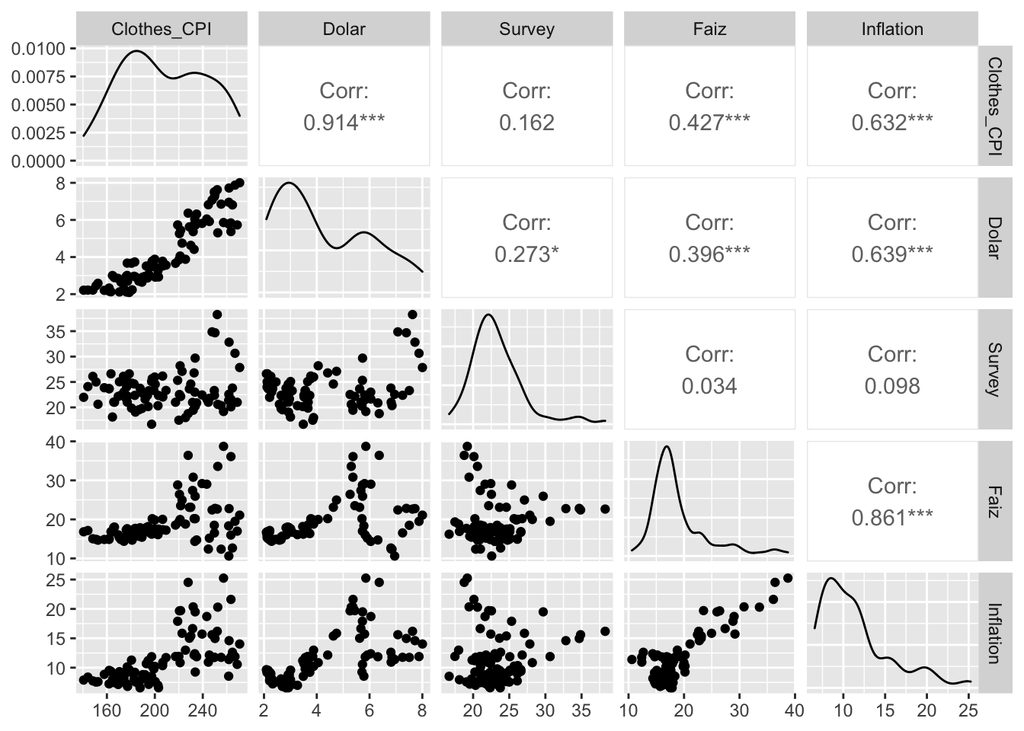

```r
ggpairs(Clothes[, .(Clothes_CPI, Dolar, Survey, Faiz, Inflation)])
```

In this table we can see that the Clothes_CPI value is significantly correlated with dolar ratio, interest rate and inflation rate. However the survey results seem to be less important. But I will use all of these regressors in order to forecast CPI index for Clothes and footwear.

4)Trend

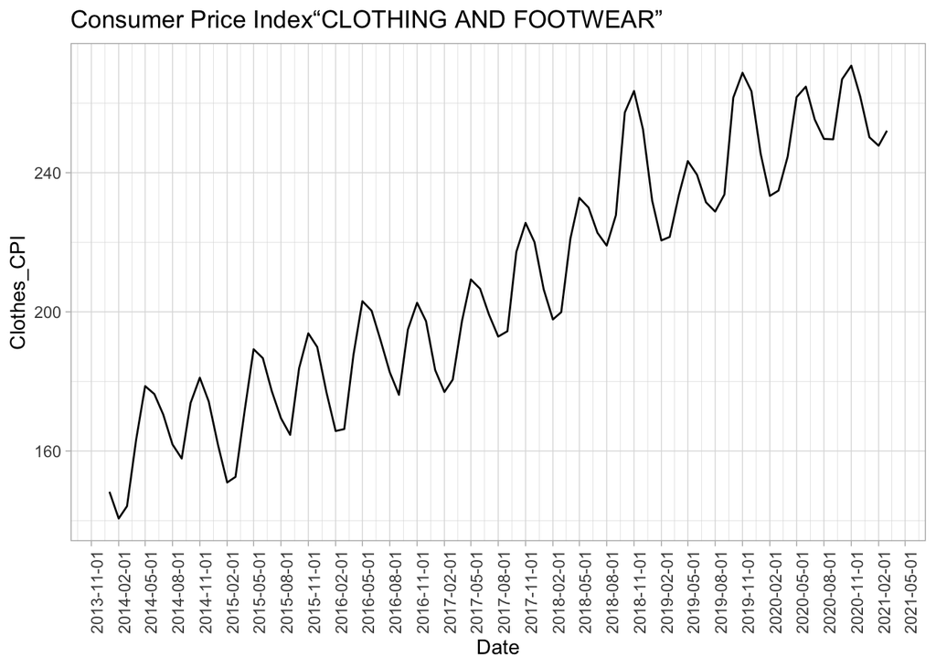

```r
Clothes[,trend:=1:.N]
reg<-lm(Clothes_CPI~trend, Clothes)
```

```
##
## Call:
## lm(formula = Clothes_CPI ~ trend, data = Clothes)
##
## Residuals:
##     Min      1Q  Median      3Q     Max
## -23.334 -10.546   0.212   8.840  35.689
##
## Coefficients:
##              Estimate Std. Error t value Pr(>|t|)
## (Intercept) 150.54817    2.78002   54.15   <2e-16 ***
## trend         1.30937    0.05487   23.86   <2e-16 ***
## ---
## Signif. codes:  0 '***' 0.001 '**' 0.01 '*' 0.05 '.' 0.1 ' ' 1
##
## Residual standard error: 12.85 on 85 degrees of freedom
## Multiple R-squared:  0.8701, Adjusted R-squared:  0.8686
## F-statistic: 569.4 on 1 and 85 DF,  p-value: < 2.2e-16
```

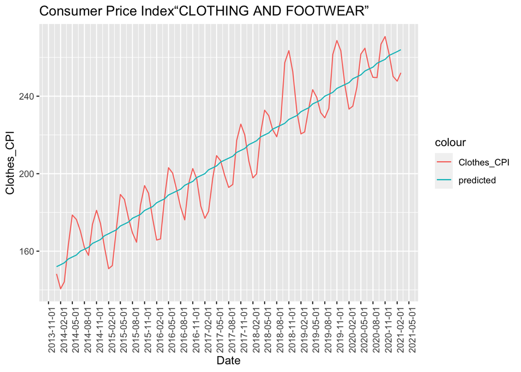

The p-value of F-statistic is very small so the trend fit with our data. So we dont have to add dummy variable. So we need to analyze the seasonality effect by autocorrelation function.

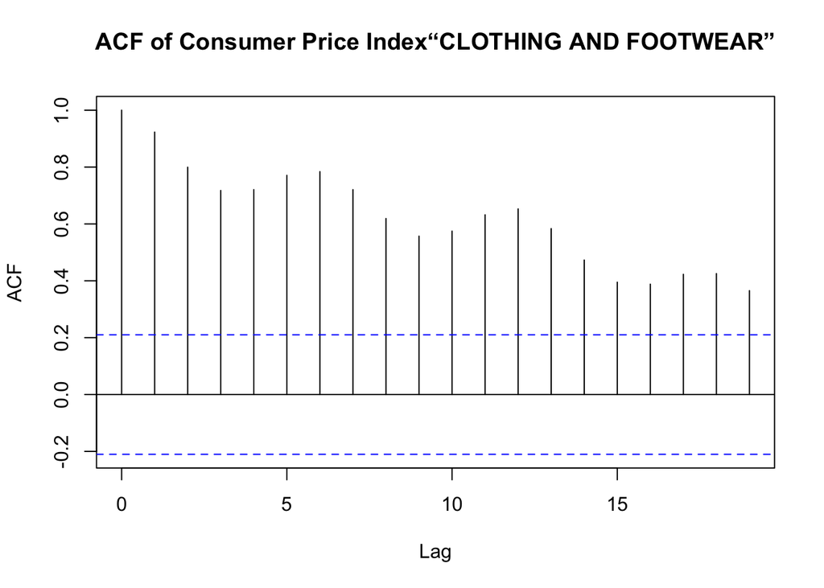

5)Regressors

As I mentioned before there are some variables which are related with Clothing_CPI. These variables are Inflation rate, Interest Rate, Dolar Rate and survey data.

Before looking to these variables we need to check residuals as a start point.

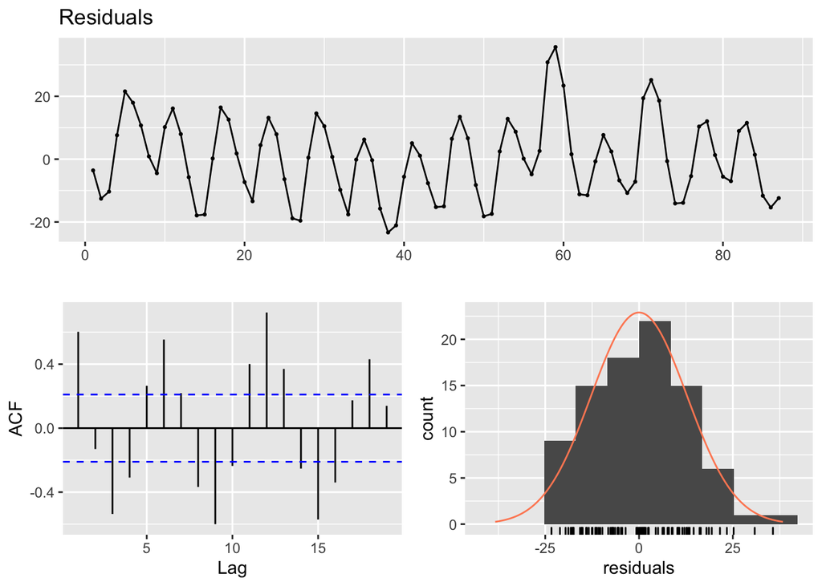

```
##
##  Breusch-Godfrey test for serial correlation of order up to 10
##
## data:  Residuals
## LM test = 75.595, df = 10, p-value = 3.644e-12
```

```r
checkresiduals(reg)
```

Residuals graphic seems to be normally distributed with a mean of zero. However there is some correlation between values and residuals violating the constant variance theory in regression.

6)Interest Rate Effect on Clothes_CPI

Interest rate effect the loans which are taken from the bank. And this situation effects the people spendings.

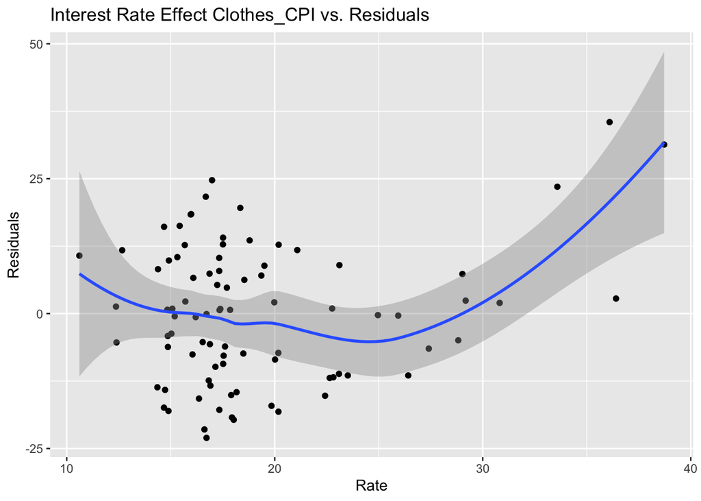

Interest Rate between 15-20 residuals seem to be random and have zero mean. If interest rate increase there is an non-linear relationship and its hard to model.

```r
reg<-lm(Clothes_CPI~trend+Faiz, Clothes)
```

```
##
## Call:
## lm(formula = Clothes_CPI ~ trend + Faiz, data = Clothes)
##
## Residuals:
##      Min       1Q   Median       3Q      Max
## -22.2152 -10.1920   0.4737   9.8734  27.7220
##
## Coefficients:
##              Estimate Std. Error t value Pr(>|t|)
## (Intercept) 141.55545    4.97313  28.464   <2e-16 ***
## trend         1.26240    0.05796  21.781   <2e-16 ***
## Faiz          0.57766    0.26736   2.161   0.0336 *
## ---
## Signif. codes:  0 '***' 0.001 '**' 0.01 '*' 0.05 '.' 0.1 ' ' 1
##
## Residual standard error: 12.58 on 84 degrees of freedom
## Multiple R-squared:  0.8769, Adjusted R-squared:  0.874
## F-statistic: 299.3 on 2 and 84 DF,  p-value: < 2.2e-16
```

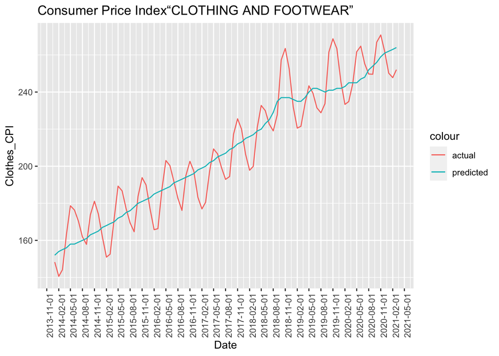

p-value is again too small however R-squared value increased a little bit and F-statistic decreased too much. Therefore interest rate data has an effect on Clothes_CPI.

After adding interest rate we check residuals again.

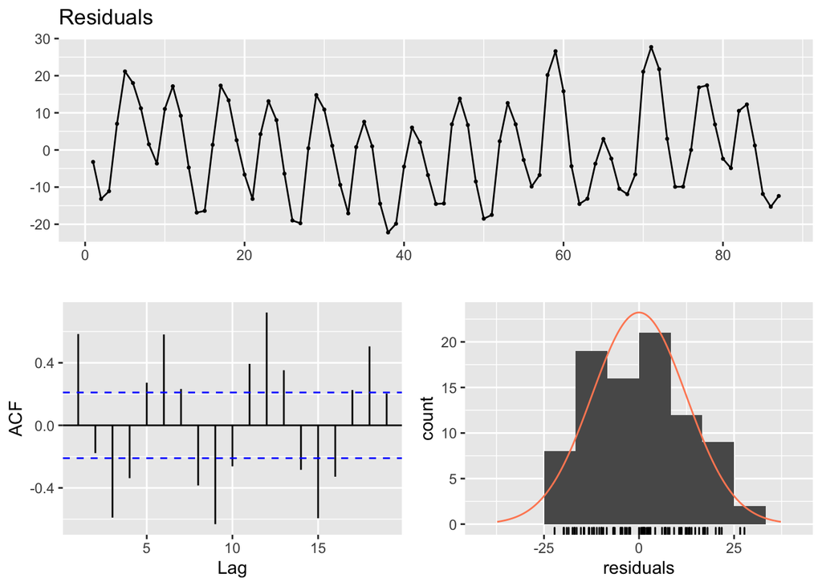

```
##
##  Breusch-Godfrey test for serial correlation of order up to 10
##
## data:  Residuals
## LM test = 74.894, df = 10, p-value = 4.99e-12
```

```r
checkresiduals(reg)
```

There is some correlation with the residual values, we can say a normal distribution applies. Zero mean rule also applies and variance is more constant.Therefore it is in a better condition than before.

7)Probability of Saving Survey Data

Probability of saving data over the next 12 months is related with Clothes_CPI. Because spending effects the Clothing_CPI

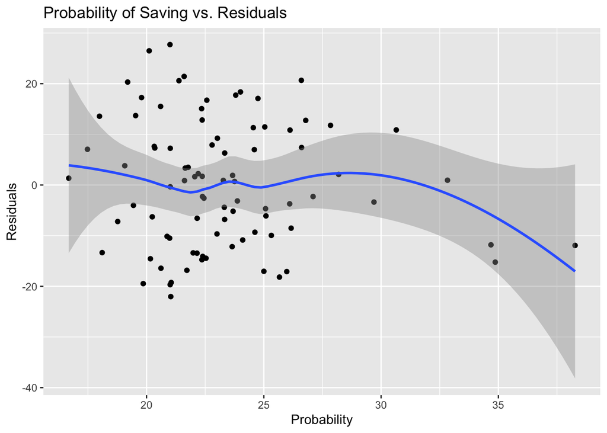

```r
reg<-lm(Clothes_CPI~trend+Faiz+Survey, Clothes)
```

```
##
## Call:
## lm(formula = Clothes_CPI ~ trend + Faiz + Survey, data = Clothes)
##
## Residuals:
##     Min      1Q  Median      3Q     Max
## -23.105  -9.634  -1.206  10.526  26.333
##
## Coefficients:
##              Estimate Std. Error t value Pr(>|t|)
## (Intercept) 150.77938    9.72431  15.505   <2e-16 ***
## trend         1.27722    0.05942  21.494   <2e-16 ***
## Faiz          0.56160    0.26741   2.100   0.0388 *
## Survey       -0.41025    0.37184  -1.103   0.2731
## ---
## Signif. codes:  0 '***' 0.001 '**' 0.01 '*' 0.05 '.' 0.1 ' ' 1
##
## Residual standard error: 12.57 on 83 degrees of freedom
## Multiple R-squared:  0.8787, Adjusted R-squared:  0.8743
## F-statistic: 200.5 on 3 and 83 DF,  p-value: < 2.2e-16
```

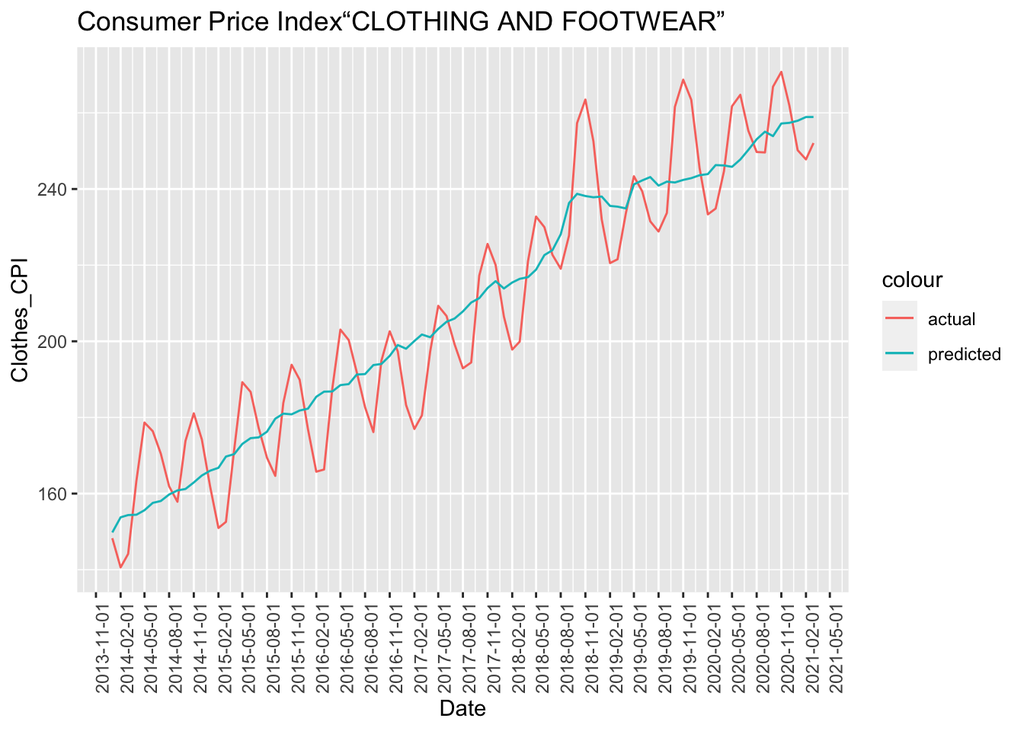

With the help of summary data again Adjusted R-squared value increased a little bit and F-statistic decreased and p-value is too small again

8)Inflation Rate

Inflation Rate is very important for products price. I mean higher inflation rate causes higher clothes prices

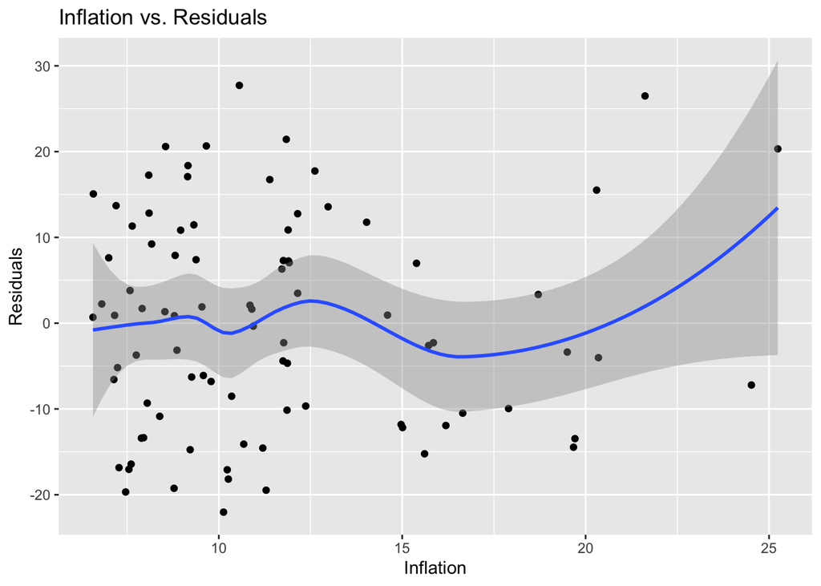

Overall we see randomly distributed residual values. But there is an observable accumulation in 0-15.0 inflation levels.Because of overestimation we should use more variables in order to increase the accuracy.

```r
reg<-lm(Clothes_CPI~trend+Faiz+Inflation, Clothes)
```

```
##
## Call:
## lm(formula = Clothes_CPI ~ trend + Faiz + Inflation, data = Clothes)
##
## Residuals:
##      Min       1Q   Median       3Q      Max
## -22.4217 -10.8127   0.1785   9.4558  28.4011
##
## Coefficients:
##              Estimate Std. Error t value Pr(>|t|)
## (Intercept) 142.63278    5.19917  27.434   <2e-16 ***
## trend         1.23071    0.07244  16.988   <2e-16 ***
## Faiz          0.24899    0.52261   0.476    0.635
## Inflation     0.57539    0.78534   0.733    0.466
## ---
## Signif. codes:  0 '***' 0.001 '**' 0.01 '*' 0.05 '.' 0.1 ' ' 1
##
## Residual standard error: 12.62 on 83 degrees of freedom
## Multiple R-squared:  0.8777, Adjusted R-squared:  0.8733
## F-statistic: 198.6 on 3 and 83 DF,  p-value: < 2.2e-16
```

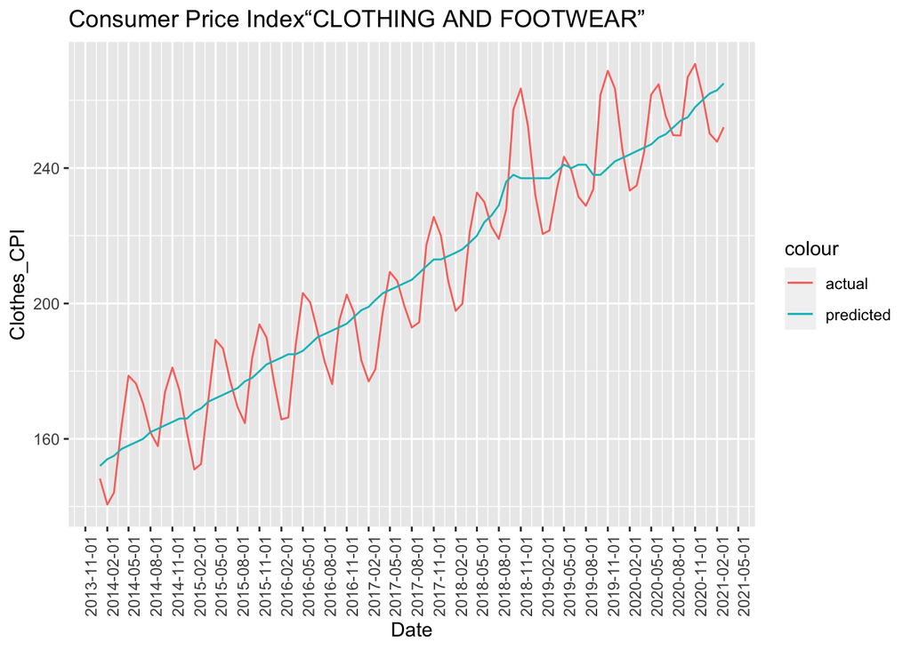

At this point, we can check the assumptions on residuals.

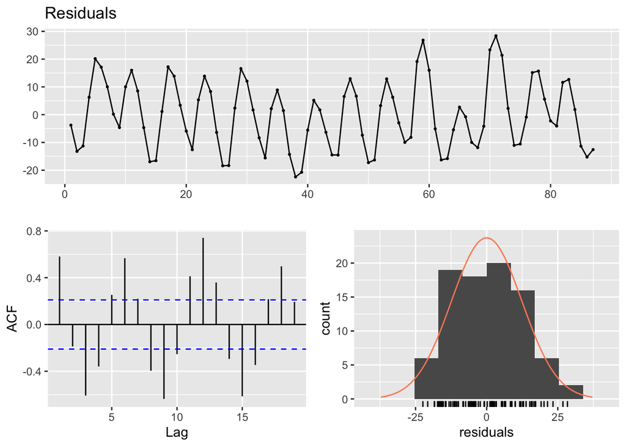

```
##
##  Breusch-Godfrey test for serial correlation of order up to 10
##
## data:  Residuals
## LM test = 75.45, df = 10, p-value = 3.888e-12
```

```r
checkresiduals(reg)
```

9)Dolar Rate

The dolar rate is related with Clothes_CPI because its effect the clothes prices.

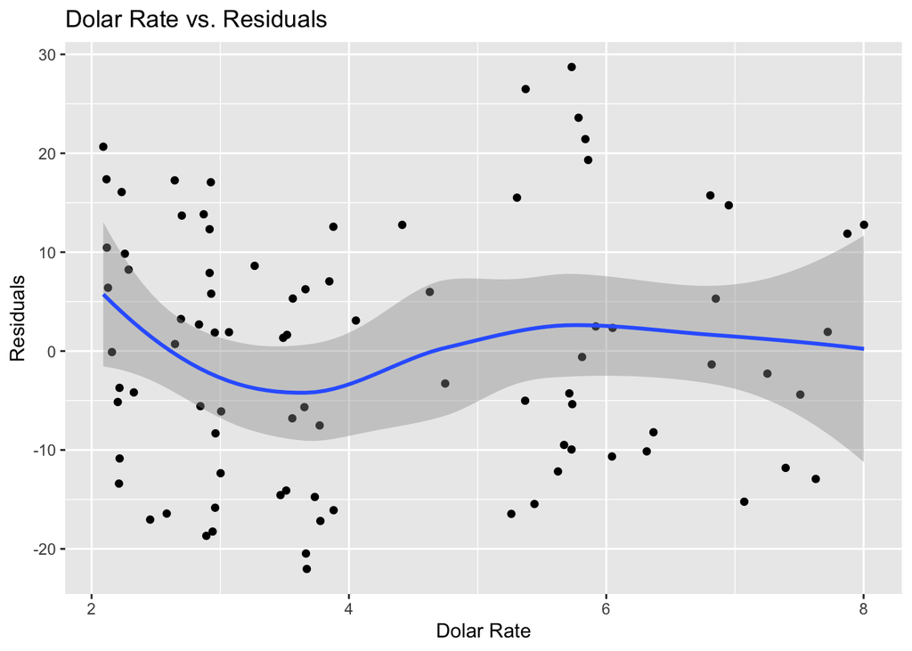

```r
reg<-lm(Clothes_CPI~trend+Faiz+Inflation+Dolar, Clothes)
```

```
##
## Call:
## lm(formula = Clothes_CPI ~ trend + Faiz + Inflation + Dolar,
##     data = Clothes)
##
## Residuals:
##     Min      1Q  Median      3Q     Max
## -21.737 -11.020  -1.224   9.215  29.079
##
## Coefficients:
##             Estimate Std. Error t value Pr(>|t|)
## (Intercept) 138.1414     6.3922  21.611  < 2e-16 ***
## trend         1.0113     0.1964   5.150 1.76e-06 ***
## Faiz          0.3617     0.5296   0.683    0.497
## Inflation     0.2962     0.8170   0.363    0.718
## Dolar         3.5639     2.9661   1.202    0.233
## ---
## Signif. codes:  0 '***' 0.001 '**' 0.01 '*' 0.05 '.' 0.1 ' ' 1
##
## Residual standard error: 12.59 on 82 degrees of freedom
## Multiple R-squared:  0.8798, Adjusted R-squared:  0.874
## F-statistic: 150.1 on 4 and 82 DF,  p-value: < 2.2e-16
```

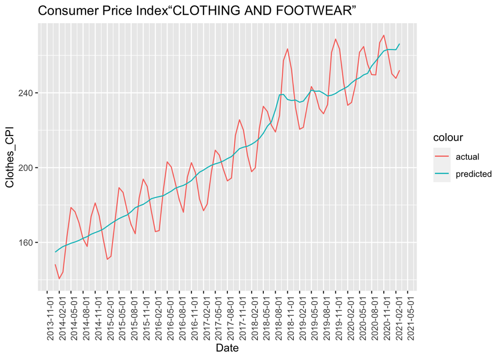

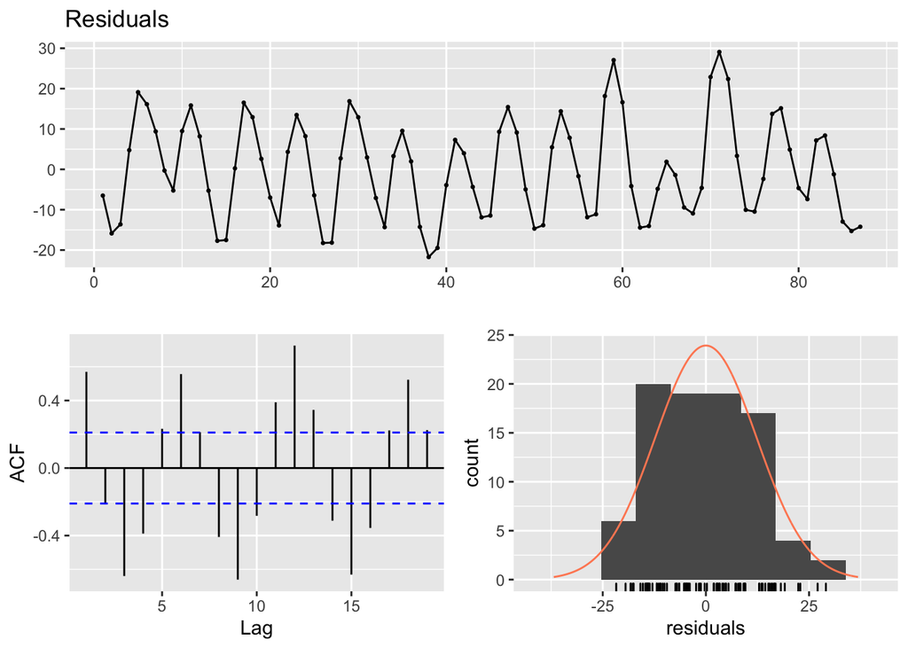

```
##
##  Breusch-Godfrey test for serial correlation of order up to 10
##
## data:  Residuals
## LM test = 74.312, df = 10, p-value = 6.474e-12
```

```r
checkresiduals(reg)
```

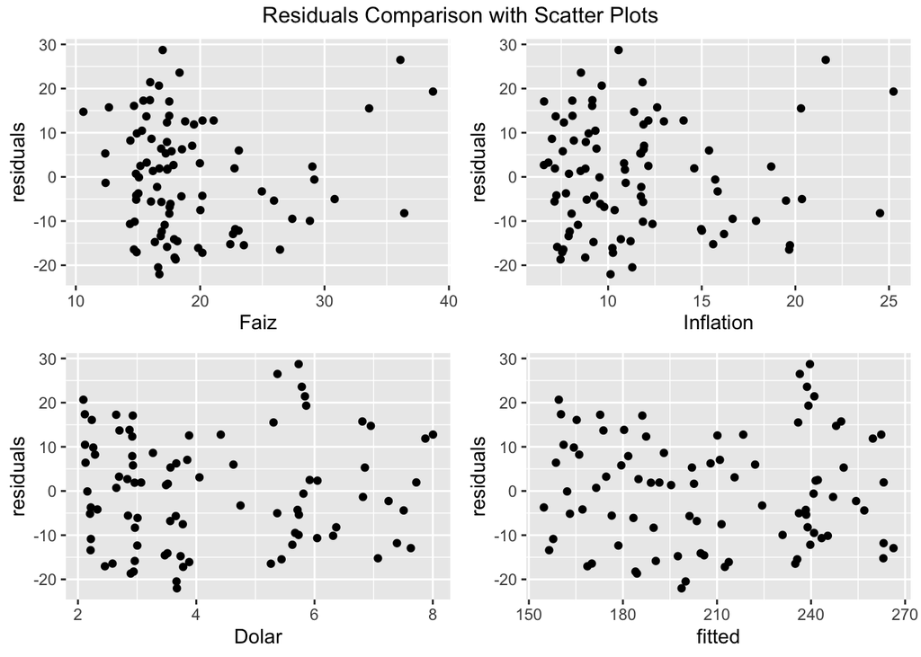

10)Forecast

```r
tail(Clothes)
```

```
##    Clothes_CPI    Dolar   Survey    Faiz Inflation       date trend predicted
## 1:      266.87 7.873881 30.64730 19.5020     11.89 2020-10-01    82  259.7053
## 2:      270.77 8.003324 27.84356 21.0825     14.03 2020-11-01    83  262.3834
## 3:      261.94 7.721065 32.83093 22.7600     14.60 2020-12-01    84  263.1643
## 4:      250.19 7.393975 34.68383 22.8180     14.97 2021-01-01    85  263.1405
## 5:      247.77 7.072365 34.86738 22.4200     15.61 2021-02-01    86  263.0512
## 6:      252.07 7.628235 38.27076 22.6425     16.19 2021-03-01    87  266.2959
##    residuals
## 1:     11.87
## 2:     12.77
## 3:      1.94
## 4:    -11.81
## 5:    -15.23
## 6:    -12.93
```

```r
interest_rate <- Clothes[Clothes$Faiz, mean(Faiz, na.rm = TRUE)]
Dolar_rate <- Clothes[Clothes$Dolar, mean(Dolar, na.rm = TRUE)]
Inflation_Rate <- Clothes[Clothes$Inflation, mean(Inflation, na.rm = TRUE)]
```

```r
forecast <- predict(reg, data.table(month="April",
                        trend = Clothes[,.N] + 1,
                        Dolar = Dolar_rate,
                        Faiz = interest_rate,
                        Inflation = Inflation_Rate))
round(forecast)
```

```
##   1
## 243
```

The survey results were not used in this forecast as a result we only used the mean values of 3 indicators:Interest,Inflation and Dolar rates.

11)Conclusion